# Notes F

Joining tables with `dplyr`

Author

EMW

Published

June 6, 2024

# `portal` dataset

The Portal Project is a long-term ecological study being conducted near Portal, AZ. Since 1977, the site has been used to study the interactions among rodents, ants and plants and their respective responses to climate. To study the interactions among organisms, we experimentally manipulate access to 24 study plots. This study has produced over 100 scientific papers and is one of the longest running ecological studies in the U.S [(Pulled directly from the Portal Project Website)](https://portal.weecology.org/)

```r
#LOAD PACKAGES
library(tidyverse)

#LOAD DATA

## Portal_rodent contains the rodent trapping data. Each individual of a target species is PIT tagged and data on species, location caught (plot and stake), sex, reproductive condition, weight, and hindfoot length are recorded.
portal_rodent <- read.csv("https://github.com/weecology/PortalData/raw/main/Rodents/Portal_rodent.csv")
```

# Warmup:

Use `group_by()` and `summarize()` to find the mean, min, and max hindfoot length for each species (using `species`). Also add the number of observations.

```r
portal_rodent %>%
    group_by(species) %>%
      summarize(mean(hfl, na.rm=T),min(hfl, na.rm=T),max(hfl, na.rm=T),n())
```

```
# A tibble: 51 × 5
   species `mean(hfl, na.rm = T)` `min(hfl, na.rm = T)` `max(hfl, na.rm = T)`
   <chr>                    <dbl>                 <dbl>                 <dbl>
 1 ""                       NaN                     Inf                  -Inf
 2 "AB"                     NaN                     Inf                  -Inf
 3 "AH"                      33                      31                    35
 4 "AS"                     NaN                     Inf                  -Inf
 5 "BA"                      13.2                     6                    21
 6 "CB"                     NaN                     Inf                  -Inf
 7 "CM"                     NaN                     Inf                  -Inf
 8 "CQ"                     NaN                     Inf                  -Inf
 9 "CS"                     NaN                     Inf                  -Inf
10 "CV"                     NaN                     Inf                  -Inf
# ℹ 41 more rows
# ℹ 1 more variable: `n()` <int>
```

```r
# NA means that at least one is missing, we can exclude it using the arguments na.rm=T
# NaN means that ALL the numbers are missing, so no value can be calculated

portal_rodent %>%
    drop_na(hfl) %>%
    group_by(species) %>%
      summarize(mean(hfl),min(hfl),max(hfl),count = n())
```

```
# A tibble: 27 × 5
   species `mean(hfl)` `min(hfl)` `max(hfl)` count
   <chr>         <dbl>      <int>      <int> <int>
 1 AH             33           31         35     2
 2 BA             13.2          6         21   388
 3 DM             35.8         21         51 17411
 4 DO             35.5         15         64  5574
 5 DS             49.9         39         58  2203
 6 DX             34           34         34     1
 7 EO             52           52         52     1
 8 OL             20.3         12         39  1347
 9 OT             19.9         11         31  4386
10 OX             19.1         13         21     8
# ℹ 17 more rows
```

What was the heaviest animal measured in each year? Return the columns `year`, `species`. Create line graph.

# Join dataframes

## Matching key variable names

What do the two letter `species_id`s really mean? Data on `species_id`s are provided in a dataset called `portal_species`.

```r
## Portal_rodent_species contains the species codes used in Portal_rodent.
portal_species <- read.csv("https://raw.githubusercontent.com/weecology/PortalData/main/Rodents/Portal_rodent_species.csv")
```

We want to have all this information in one data frame instead of two separate data frames.

The variable `species` in `portal_rodents` match the variable `speciescode` in the `portal_species` dataset – this is our *key variable*. In this case, they actually have different names, but this doesn’t necessarily have to be true.

```r
table <- portal_rodent %>%
    drop_na(hfl) %>%
    group_by(species) %>%
      summarize(mean_hfl = mean(hfl),min_hfl= min(hfl),max_hfl = max(hfl),count = n())
```

```r
portal_joined <- table %>%
  left_join(portal_species, by = c("species" = "speciescode"))

portal_joined %>%
  select(species, scientificname, commonname, mean_hfl, min_hfl, max_hfl, count)
```

```
# A tibble: 27 × 7
   species scientificname           commonname    mean_hfl min_hfl max_hfl count
   <chr>   <chr>                    <chr>            <dbl>   <int>   <int> <int>
 1 AH      Ammospermophilus harrisi Harris's ant…     33        31      35     2
 2 BA      Baiomys taylori          Northern pyg…     13.2       6      21   388
 3 DM      Dipodomys merriami       Merriam's ka…     35.8      21      51 17411
 4 DO      Dipodomys ordii          Ord's kangar…     35.5      15      64  5574
 5 DS      Dipodomys spectabilis    Banner-taile…     49.9      39      58  2203
 6 DX      Dipodomys sp.            Kangaroo rat      34        34      34     1
 7 EO      Eumeces obsoletus        Great Plains…     52        52      52     1
 8 OL      Onychomys leucogaster    Northern Gra…     20.3      12      39  1347
 9 OT      Onychomys torridus       Southern gra…     19.9      11      31  4386
10 OX      Onychomys sp.            Grasshopper …     19.1      13      21     8
# ℹ 17 more rows
```

## Multiple Key variables

```r
portal_weather <- read.csv("https://github.com/weecology/PortalData/raw/main/Weather/Portal_weather.csv")

#mean daily temperature
portal_weather_daily <- portal_weather %>%
  group_by(year, month, day) %>%
  summarize(mean_airtemp = mean(airtemp, na.rm=T))
```

```r
#join
portal_rodent_weather <- portal_rodent %>%
  left_join(portal_weather_daily, by = c("year", "month", "day"))

portal_rodent_weather
```

[output not shown]

[output cut: 12486 more lines]

## Why is this useful?

Exploring relationships between variables in separate tables:

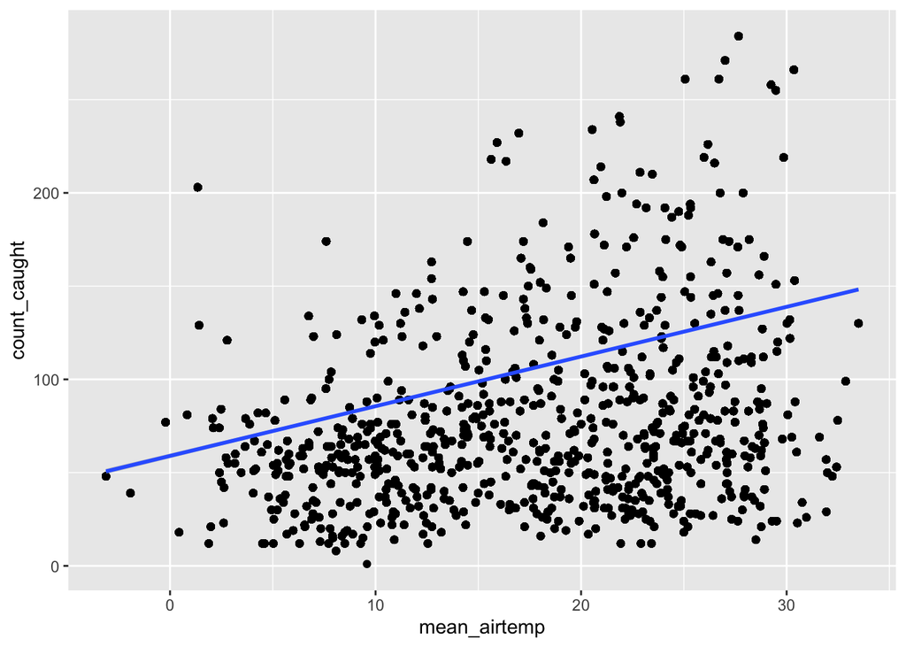

```r
portal_rodent_weather %>%
   group_by(year, month, day) %>%
   summarize(count_caught = n(), mean_airtemp = mean_airtemp) %>%
   ggplot(aes(x=mean_airtemp, y=count_caught)) +
   geom_point() +
   geom_smooth(method='lm')
```

# Common Issues with Joining

- duplicate keys
- lowercase/uppercase
- symbols or whitespace
- Make sure the join fields are the same format.